# Master programming

Лекция №8 (Обзор boost::spirit)

Игорь Шаронов

2018-11-06

# Знакомство с boost::spirit

# Из чего состоит грамматика языка?

- Связующее звено между представлениями одних и тех же сущностей
- AST — abstract syntax tree
- [EBNF (Extended Backus-Naur Form)](https://ru.wikipedia.org/wiki/Расширенная_форма_Бэкуса_—_Наура) — язык описания грамматики
- Рекурсивность, как полнота грамматики
- PEG (Parsing Expression Grammar) — Domain Specific Embedded Language

[boost::spirit::x3](https://ciere.com/cppnow15/using_x3.pdf)

# Концепты spirit-а

`x3::rule<ID, Attribute>`

- **Правила** составляются из **парсеров**, которые захватывают **атрибуты**
  - Synthesized attribute — атрибут по умолчанию
  - Compatible attribute — совместимый (конвертируемый) атрибут (`std::string` и `std::vector<char>`)
- Грамматика — набор правил и специальных атрибутов для построения AST

[figure not shown]

Пример вывода правил

# Примитивные парсеры

- `int_`, `short_`, `long_`, `int_(42)`, … — парсеры целых чисел
- `double_`, `float_`, `double_(42.2)`, … — парсеры действительных чисел
- `bool_`, `true_`, `false_` — булевы парсеры
- `lit("abc")`, `char_`, `char_("A-Za-z")`, … — литеральные парсеры (точное соответствие строке)
- `alnum`, `blank`, `space`, `lower`, … — классификаторы
- `parse` — разбор выражения
- `phrase_parse` — более “тонкий” разбор выражения

```cpp
namespace x3 = boost::spirit::x3;
std::string_view text{"123546"};
bool parsed = x3::parser(text.begin(), text.end(), x3::int_);
```

# Основные операторы boost::spirit

PEG Operators

| Description | PEG | Spirit X3 | Example |
| --- | --- | --- | --- |
| Sequence | a b | a >> b | `int_ >> ' ' >> double_` |
| Alternative | a\|b | a\|b | `alpha \| digit` |
| Zero or more (Kleene) | a* | *a | `alpha >> *(',' >> alnum)` |
| One or more (Plus) | a+ | +a | `+alnum >> '_'` |
| Optional | a? | -a | `-alpha >> int_` |
| And-predicate | &a | &a | `int_ >> &char_(';')` |
| Not-predicate | !a | ~a | `~char_('"')` |
| Difference |  | a - b | `"/*" >> *(char_ - "*/") >> "*/"` |
| Expectation |  | a > b | `lit('c') > "++"` |
| List |  | a % b | `int_ % ','` |

# Формирование правил

- Именованные парсеры
- Можно указать тип атрибута
- Позволяет использовать рекурсивность парсеров
- Предоставляет обработчик ошибок (`on_error`)
- Использование пользовательских функций для определения успешного парсинга (`on_success`)

# Примеры парсеров

# Последовательный парсинг

```cpp
namespace x3 = boost::spirit::x3;
std::string_view text{"123 45.6"};
bool parsed = x3::parser(text.begin(), text.end(), x3::int_ >> ' ' >> x3::double_);
```

# Парсер файла формата ключ-значение

```cpp
std::string_view text{R"(foo: bar,
    gorp : smart ,
    falcou : "crazy frenchman",
    name:sam)"};

x3::phrase_parse(text.begin(), text.end(),
                 (name >> ':' >> (quote | name)) % ',',
                 x3::space);
```

# Правила

```cpp
auto name = x3::rule<class name, std::string>{} // явное прописывание тэга и атрибута
          = x3::alpha >> *x3::alnum; // переменные в C-стиле
auto quote = '"' >> x3::lexeme[*(~x3::char_('"'))] >> '"'; // строковые значения в кавычках
```

# Атрибуты

# Получение результата парсинга

- AST — удобное представление через ассоциативный рекурсивный массив
- Атрибут — результат, который предоставляет конкретный парсер
- Литералы не имеют атрибутов
- Примитивные парсеры (`int_`, `double_`, …) имеют примитивные по типу атрибуты (`int`, `double`, …)
- Нетерминалы вида `x3::rule<ID, A>` имеют атрибут `A`

Атрибуты операторов

| Оператор | Его синтезируемый атрибут |
| --- | --- |
| `a >> b` | `tuple<A, B>` |
| `a \| b` | `boost::variant<A, B>` |
| `*a`, `+a` | `std::vector<A>` |
| `-a` | `boost::optional<A>` |
| `&a`, `~a` | нет атрибута |
| `a % b` | `std::vector<A>` |

# Примеры

```cpp
std::string_view text{"pizza"};

std::string result; // совместимо с атрибутом std::vector<char>
x3::parse(text.begin(), text.end(), *x3::char_, result);
```

```cpp
std::string_view text{"cosmic pizza"};

std::string result0;
std::string result1;
x3::parse(text.begin(), text.end(), *(~x3::char_(' ')) >> ' ' >> *x3::char_, result0, result1);

std::pair<std::string, std::string> result;
x3::parse(text.begin(), text.end(), *(~x3::char_(' ')) >> ' ' >> *x3::char_, result);
```

# Разбор с атрибутами примера ключ-значение

```cpp
std::string_view text{R"(foo: bar,
    gorp : smart ,
    falcou : "crazy frenchman",
    name:sam)"};

auto name = x3::alpha >> *x3::alnum;
auto qoute = '"' >> x3::lexeme[*(~x3::char_('"'))] >> '"';
auto item = x3::rule<class item, std::pair<std::string, std::string>>>{}
          = name >> ':' >> (quote | name);

std::map<std::string, std::string> dict;
x3::phrase_parse(text.begin(), text.end(), item % ',', x3::space, dict);
```

```
a: char, b: vector<char> → (a >> b): tuple<char, vector<char>> → vector<char> → string
a: unused, b: vector<char>, c: unused → (a >> b >> c): vector<char> → string
a: string, b: string → (a | b): variant<string, string> → string
a: string, b: unused, c: string → (a >> b >> c): tuple<string, string>
a: pair<string, string>, b: unused → (a % b): vector<pair<string, string>> → map<string, string>
```

# Построение грамматик

# Что нужно для полного построения правила?

1. Тип атрибута
2. Идентификатор правила
3. Тип правила
4. Определение правила
5. Само правило

```cpp
struct my_type { ... };
struct my_rule_class;
const x3::rule<my_rule_class, my_type> my_rule_type = "my_rule";
const auto my_rule_def = x3::lexeme[(x3::alpha | '_') >> *(x3::alnum | '_')];
BOOST_SPIRIT_DEFINE(my_rule)
```

# Обработка ошибок

https://www.boost.org/doc/libs/1_68_0/libs/spirit/doc/x3/html/spirit_x3/tutorials/error_handling.html

https://github.com/djowel/spirit_x3/blob/master/example/x3/calc5.cpp

# Что дальше

- Рекурсивные типы через `boost::forward_ast`
- Оператор строгого следования `>`
- Явное прописывание генерируемого атрибута: `"abc" > x3::attr(10)`

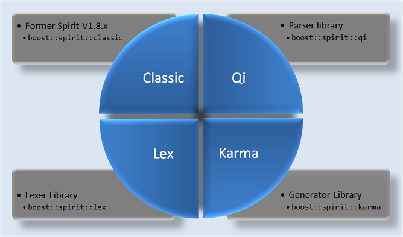

Структура `boost::spirit`

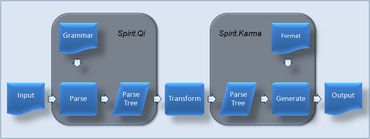

Разница между qi и karma

- И где здесь `x3`??